# R script:Cheat-sheet

## Plotting functions in ggplot2

Create a histogram using ggplot2

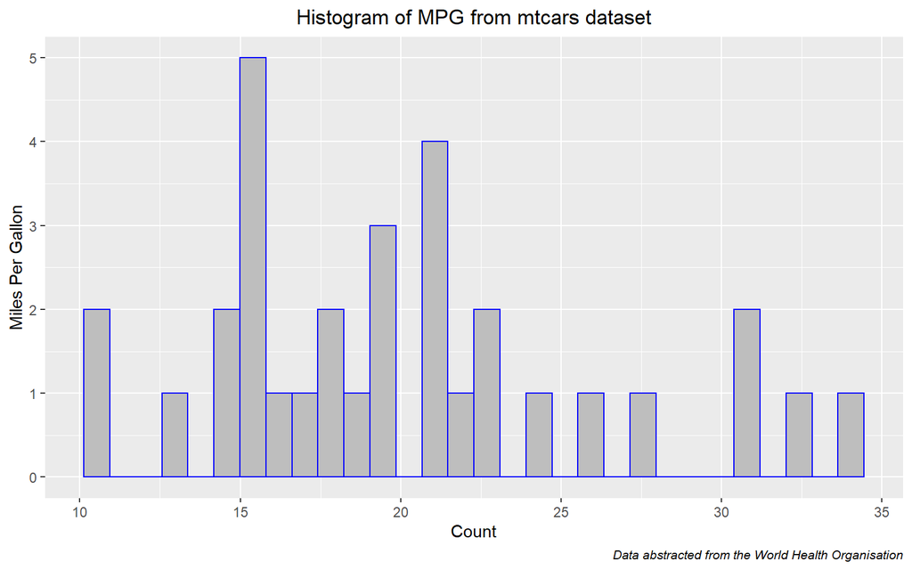

```r
df <- mtcars


ggplot(data = df, aes(x = mpg)) + geom_histogram(color = "blue", fill = "gray") +
    # provide fill for filling bars and color for border of bars
labs(title = "Histogram of MPG from mtcars dataset", x = "Count", y = "Miles Per Gallon",
    caption = "Data abstracted from the World Health Organisation") + # labelling of the histogram
theme(plot.title = element_text(hjust = 0.5)) + # center the plot title
theme(plot.caption = element_text(face = "italic", size = 8))
```

When using theme from the *ggthemes*, remember that the theme will have its own default regarding font type, font size … Hence, to maintain consistent format, user can create own theme using *theme_foundation* provided in theme library.

## Saving ggplot2 with high resolution and custom spefications:

The plot created above can now be saved with desired resolution and plot dimensions and plot type.

```r
# recreate plot again and put it into an object a

df <- mtcars


a <- ggplot(data = df, aes(x = mpg)) + geom_histogram(color = "blue", fill = "gray") +
    # provide fill for filling bars and color for border of bars
labs(title = "Histogram of MPG from mtcars dataset", x = "Count", y = "Miles Per Gallon",
    caption = "Data abstracted from the World Health Organisation") + # labelling of the histogram
theme(plot.title = element_text(hjust = 0.5)) + # center the plot title
theme(plot.caption = element_text(face = "italic", size = 8))

# now to save the plot.

# ggsave(a, height = 5, width = 7, filename = 'MYPATHHERE.plottype', units =
# 'in', dpi = DESIRED_PLOT_DPI_HERE)

# standard dpi for color plots should be between 600 - 1200 dpi.
```

## Base R method to save a ggplot2 graph

This is the base R method to save a ggplot2 graph. Naturally, it can be also used to save a base R plot. This should be the default method to save a Kaplan Meier plot created using the *ggsurvplot* function in *survminer* package as it will work when there is a risk table below the plot. The *ggsave* function will not work when there is a risk table below the KM plot created with *ggsurvplot*.

```r
# tiff('MYPATHHERE.tiff', height = 5, width = 7, device = 'tiff', res = 900) #
# PRINT GGPLOT2 OBJECT NAME HERE dev.off()

# to save as PDF, change call to pdf and device to pdf.

# for survminer graphs---

# tiff('MYPATHHERE.tiff', height = 5, width = 7, device = 'tiff', res = 900)
# print(PRINT GGPLOT2 OBJECT NAME HERE) dev.off()
```

## Moving columns around in the dataset

If we want to move columns around to keep those use more in the front

```r
moveme <- function(invec, movecommand) {
    movecommand <- lapply(strsplit(strsplit(movecommand, ";")[[1]], ",|\\s+"), function(x) x[x !=
        ""])
    movelist <- lapply(movecommand, function(x) {
        Where <- x[which(x %in% c("before", "after", "first", "last")):length(x)]
        ToMove <- setdiff(x, Where)
        list(ToMove, Where)
    })
    myVec <- invec
    for (i in seq_along(movelist)) {
        temp <- setdiff(myVec, movelist[[i]][[1]])
        A <- movelist[[i]][[2]][1]
        if (A %in% c("before", "after")) {
            ba <- movelist[[i]][[2]][2]
            if (A == "before") {
                after <- match(ba, temp) - 1
            } else if (A == "after") {
                after <- match(ba, temp)
            }
        } else if (A == "first") {
            after <- 0
        } else if (A == "last") {
            after <- length(myVec)
        }
        myVec <- append(temp, values = movelist[[i]][[1]], after = after)
    }
    myVec
}

# this is primarily for vectors eg. moveMe(names(df),'g first') = will insert g
# as the first column moveMe(names(df), 'g first; a last; e before c') = will do
# exactly as written in the code for dataframes , we need to use:
# df[moveMe(names(df),'g first')]
```

```r
df <- mtcars

names(mtcars)
```

```
 [1] "mpg"  "cyl"  "disp" "hp"   "drat" "wt"   "qsec" "vs"   "am"   "gear"
[11] "carb"
```

```r
df2 <- df[moveme(names(df), "disp first")]

names(df2)  # now df2 contains disp as the first column.
```

```
 [1] "disp" "mpg"  "cyl"  "hp"   "drat" "wt"   "qsec" "vs"   "am"   "gear"
[11] "carb"
```

```r
df2 <- df[moveme(names(df), "drat last")]

names(df2)  # now drat is last
```

```
 [1] "mpg"  "cyl"  "disp" "hp"   "wt"   "qsec" "vs"   "am"   "gear" "carb"
[11] "drat"
```

*moveMe* function will move the column to the first or last position of the dataset.

## Example using data.table package which has a function similar to the LIKE in SQL.

```r
## Create the data.table:
DT = data.table(Name = c("Mary", "George", "Martha"), Salary = c(2, 3, 4))

## Subset the DT table where the Name column is like 'Mar%':
DT[Name %like% "^Mar"]
```

```
     Name Salary
1:   Mary      2
2: Martha      4
```

```r
## Name Salary 1: Mary 2 2: Martha 4
```